# WQD7004-OCC3&RL: Group Assignment(Group 9)

### 3.3.6 Class

**Different perspectives from Flight Class**

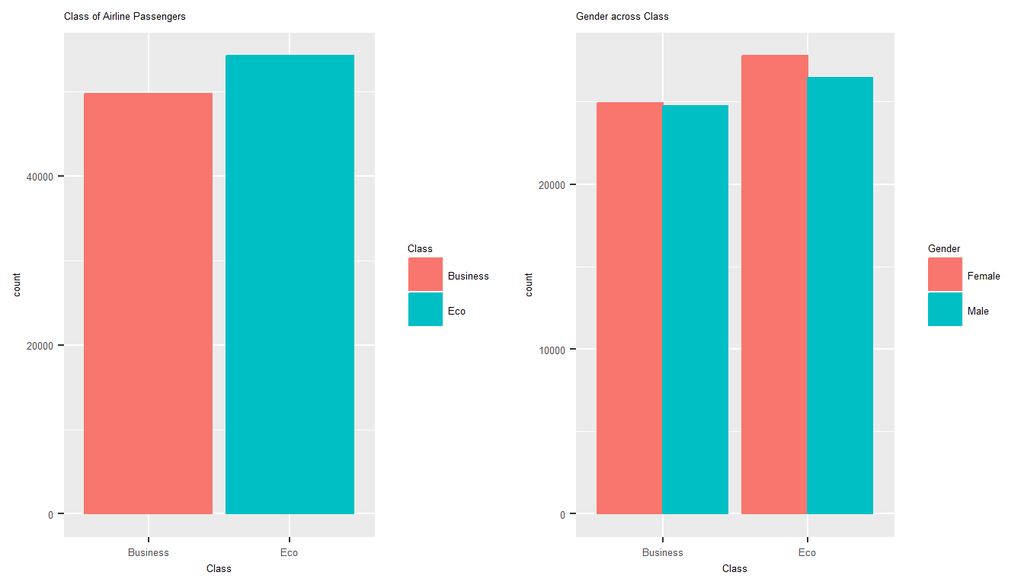

- The distribution of passengers between business and economy class is roughly equal, with a nearly equal number of male and female passengers in both classes.

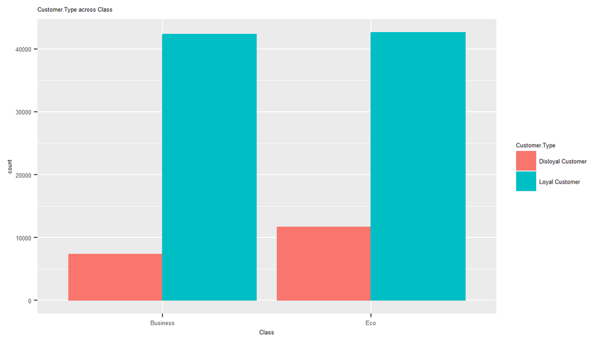

- In addition, the customer demographic in both business and economy class is similar, with the majority of passengers being Loyal Customers and a small percentage being Disloyal Customers.

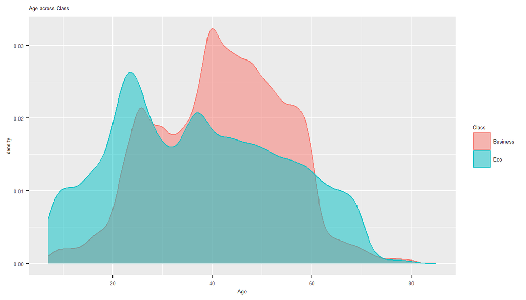

- In economy class, there is a higher proportion of passengers aged below 30 and between 60 to 70 years old, whereas in business class, there is a higher proportion of passengers aged between 30 to 60 years old. The demographic differences between economy and business class passengers could be due to various factors such as pricing, travel purpose, life stage and perception of comfort.
- Younger passengers might choose Eco class due to cost concerns, as it is typically the most affordable option. They might also be more likely to be traveling for leisure or personal reasons rather than for work, leading them to prioritize cost savings over amenities. Alternatively, younger passengers might prioritize other aspects of their trip, such as destination or duration, and choose the Eco class in order to allocate more of their budget to those factors.
- Business class is often chosen by adults for the enhanced comfort it provides, such as more spacious seating and additional amenities. It may also be preferred for the convenience it offers, including priority services at the airport and access to exclusive lounges. The ability to work or relax in a more comfortable setting during long flights can also be a factor in the choice of business class. Additionally, some adults may be attracted to the prestige associated with flying in this class.

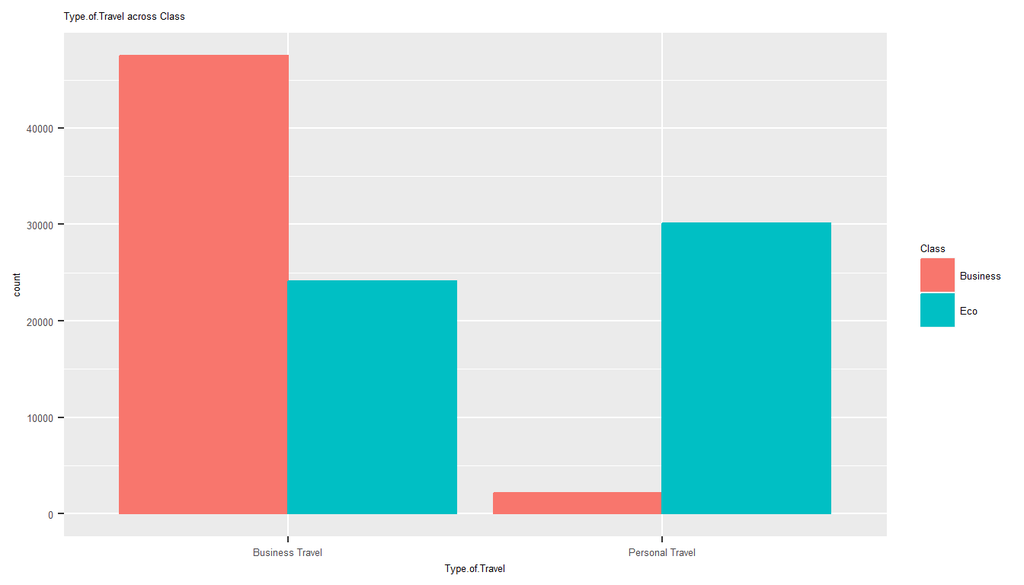

- According to the graph, a significant number of business class passengers are traveling for business purposes. While the Eco class also has a proportion of business travelers, there is a slightly higher percentage of passengers traveling for personal reasons.

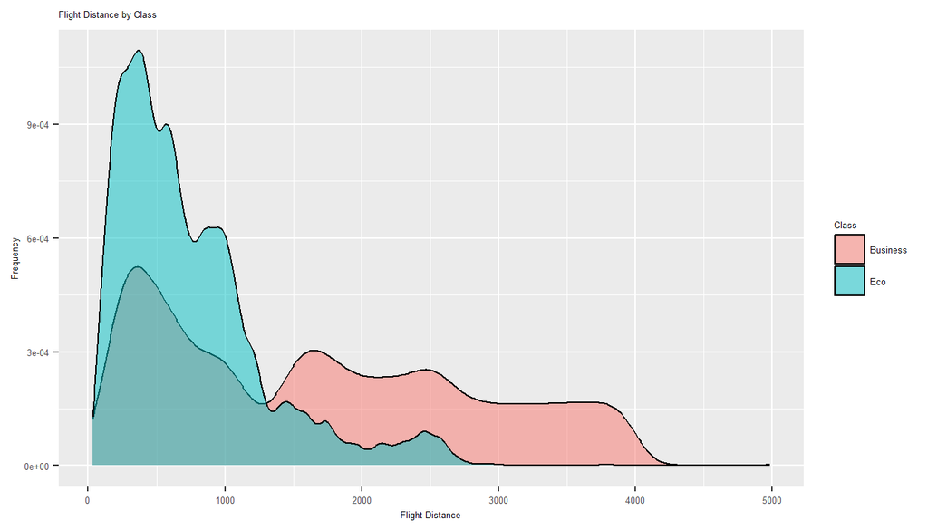

- From the graph, we can see that passengers often choose business class for further flights. It may because of the added comfort and amenities on long flights.

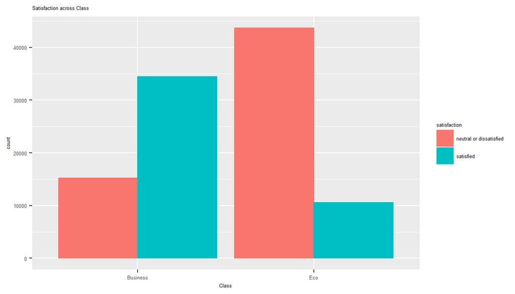

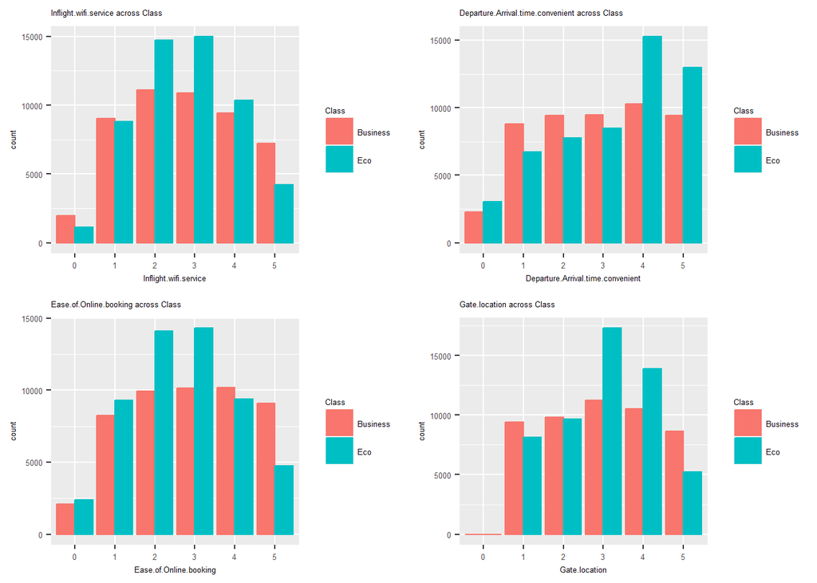

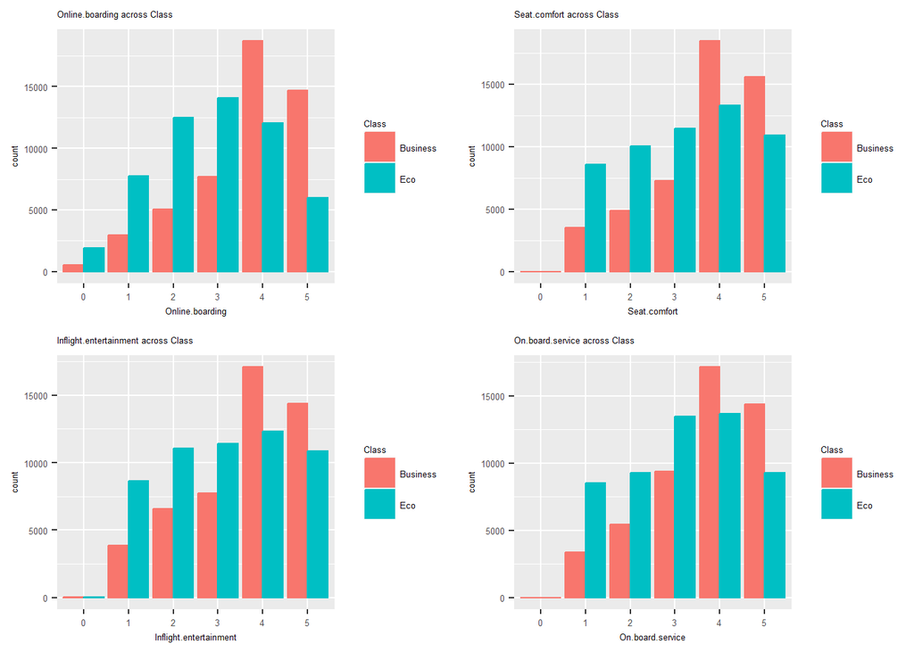

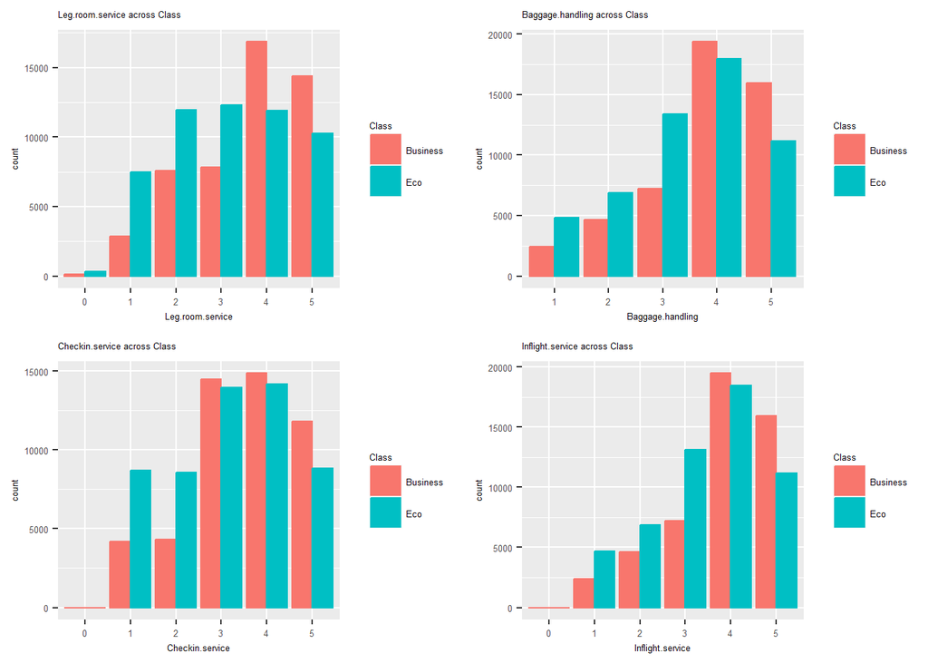

## 3.4 Classification

Classification is the process of predicting the target label based on features in the dataset. In this project, we will build classification model using different algorithms to predict the satisfaction of customers (either satisfied or neutral/dissatisfied) based on available features such as customer demographics, flight details, service ratings etc.

### 3.4.1 Handle Categorical Data

Convert categorical data to numerical data using:  
**Ordinal Data**  
Convert Ordinal to Integer

```r
airline_df_m <- airline_df
ord_ratings <- c("Inflight.wifi.service", "Food.and.drink", "Seat.comfort",
          "Departure.Arrival.time.convenient",  "Ease.of.Online.booking",
          "Gate.location", "Online.boarding", "Inflight.entertainment",
          "On.board.service",   "Leg.room.service", "Baggage.handling",
          "Checkin.service",    "Inflight.service", "Cleanliness"
          )
airline_df_m[ord_ratings] <-
  lapply(airline_df_m[ord_ratings],
         function(x) as.numeric(as.character(x))
         )
```

**Nominal Data**  
One-hot encoding to convert each category into a new column and assign a value as 1 or 0 to the column

```r
# One-Hot encoding
features <- c("Gender", "Customer.Type",    "Age", "Type.of.Travel", "Class",
              "Flight.Distance", ord_ratings, "Departure.Delay.in.Minutes",
              "Arrival.Delay.in.Minutes")
airline_df_m_trsf <-
  cbind(data.frame(predict(dummyVars(
          ~.,
          data = airline_df_m),
          airline_df_m)
          ),
        satisfaction = airline_df_m$satisfaction
        )
airline_df_m_trsf <- subset(airline_df_m_trsf,
                            select = -c(satisfaction.neutral.or.dissatisfied,
                                        satisfaction.satisfied, id))

# Remove perfectly correlated variables
airline_df_m_trsf <- subset(airline_df_m_trsf,
                            select = -c(Gender.Male, Customer.Type.Loyal.Customer,
                                        Type.of.Travel.Personal.Travel, Class.Eco))

# Set satisfaction as factors
airline_df_m_trsf$satisfaction <- factor(airline_df_m_trsf$satisfaction)
```

### 3.4.2 Correlation

Further investigation on the correlation between different airline services and overall satisfaction. It is observed that the class and online boarding service have a stronger positive correlation with the overall satisfaction, i.e. more than 0.5 Pearson correlation coefficient. Passengers rely on the type of flight class and the online boarding service to rate higher satisfaction for the flight.

```r
#Changing Satisfaction attribute to numeric
airline_corr<- airline_df_m_trsf %>%
  select(everything()) %>%   mutate_if(is.factor,as.numeric)
str(airline_corr)
```

```
## 'data.frame':    103904 obs. of  23 variables:
##  $ Gender.Female                    : num  0 0 1 1 0 1 0 1 1 0 ...
##  $ Customer.Type.Disloyal.Customer  : num  0 1 0 0 0 0 0 0 0 1 ...
##  $ Age                              : num  13 25 26 25 61 26 47 52 41 20 ...
##  $ Type.of.Travel.Business.Travel   : num  0 1 1 1 1 0 0 1 1 1 ...
##  $ Class.Business                   : num  0 1 1 1 1 0 0 1 1 0 ...
##  $ Flight.Distance                  : num  460 235 1142 562 214 ...
##  $ Inflight.wifi.service            : num  3 4 2 2 3 4 2 4 1 4 ...
##  $ Departure.Arrival.time.convenient: num  4 2 2 5 3 4 4 3 2 3 ...
##  $ Ease.of.Online.booking           : num  3 3 2 5 3 2 2 4 2 3 ...
##  $ Gate.location                    : num  1 3 2 5 3 1 3 4 2 4 ...
##  $ Food.and.drink                   : num  5 1 5 2 4 1 2 3 4 2 ...
##  $ Online.boarding                  : num  3 3 5 2 5 2 2 5 3 3 ...
##  $ Seat.comfort                     : num  5 1 3 3 3 3 3 3 3 3 ...
##  $ Inflight.entertainment           : num  5 1 5 2 3 1 2 5 1 2 ...
##  $ On.board.service                 : num  4 1 4 2 3 3 3 5 1 2 ...
##  $ Leg.room.service                 : num  3 5 3 5 4 4 3 5 2 3 ...
##  $ Baggage.handling                 : num  4 3 4 3 4 4 4 5 1 4 ...
##  $ Checkin.service                  : num  4 1 4 1 3 4 3 4 4 4 ...
##  $ Inflight.service                 : num  5 4 4 4 3 4 5 5 1 3 ...
##  $ Cleanliness                      : num  5 1 5 2 3 1 2 4 2 2 ...
##  $ Departure.Delay.in.Minutes       : num  25 1 0 11 0 0 9 4 0 0 ...
##  $ Arrival.Delay.in.Minutes         : num  18 6 0 9 0 0 23 0 0 0 ...
##  $ satisfaction                     : num  1 1 2 1 2 1 1 2 1 1 ...
```

```r
#Creating correlation between different airline services and overall satisfaction.
df_corr<-cor(airline_corr[-1], airline_corr$satisfaction)
colnames(df_corr)[1] <- "Satisfaction"
df_corr
```

```
##                                    Satisfaction
## Customer.Type.Disloyal.Customer   -0.1876381714
## Age                                0.1371673050
## Type.of.Travel.Business.Travel     0.4490004498
## Class.Business                     0.5038484626
## Flight.Distance                    0.2987797858
## Inflight.wifi.service              0.2838195658
## Departure.Arrival.time.convenient -0.0516006177
## Ease.of.Online.booking             0.1717049785
## Gate.location                      0.0006820275
## Food.and.drink                     0.2097962131
## Online.boarding                    0.5035573216
## Seat.comfort                       0.3492676800
## Inflight.entertainment             0.3980594211
## On.board.service                   0.3223825215
## Leg.room.service                   0.3131308017
## Baggage.handling                   0.2477493654
## Checkin.service                    0.2361737428
## Inflight.service                   0.2447407387
## Cleanliness                        0.3051980118
## Departure.Delay.in.Minutes        -0.0504942103
## Arrival.Delay.in.Minutes          -0.0574353182
## satisfaction                       1.0000000000
```

```r
#Creating correlation heatmap between different attributes.
corr_mat <- round(cor(airline_corr),2)
head(corr_mat)
```

```
##                                 Gender.Female Customer.Type.Disloyal.Customer
## Gender.Female                            1.00                            0.03
## Customer.Type.Disloyal.Customer          0.03                            1.00
## Age                                     -0.01                           -0.28
## Type.of.Travel.Business.Travel           0.01                            0.31
## Class.Business                          -0.01                           -0.09
## Flight.Distance                         -0.01                           -0.23
##                                   Age Type.of.Travel.Business.Travel
## Gender.Female                   -0.01                           0.01
## Customer.Type.Disloyal.Customer -0.28                           0.31
## Age                              1.00                           0.05
## Type.of.Travel.Business.Travel   0.05                           1.00
## Class.Business                   0.14                           0.55
## Flight.Distance                  0.10                           0.27
##                                 Class.Business Flight.Distance
## Gender.Female                            -0.01           -0.01
## Customer.Type.Disloyal.Customer          -0.09           -0.23
## Age                                       0.14            0.10
## Type.of.Travel.Business.Travel            0.55            0.27
## Class.Business                            1.00            0.47
## Flight.Distance                           0.47            1.00
##                                 Inflight.wifi.service
## Gender.Female                                   -0.01
## Customer.Type.Disloyal.Customer                 -0.01
## Age                                              0.02
## Type.of.Travel.Business.Travel                   0.10
## Class.Business                                   0.03
## Flight.Distance                                  0.01
##                                 Departure.Arrival.time.convenient
## Gender.Female                                               -0.01
## Customer.Type.Disloyal.Customer                             -0.21
## Age                                                          0.04
## Type.of.Travel.Business.Travel                              -0.26
## Class.Business                                              -0.10
## Flight.Distance                                             -0.02
##                                 Ease.of.Online.booking Gate.location
## Gender.Female                                    -0.01          0.00
## Customer.Type.Disloyal.Customer                  -0.02          0.01
## Age                                               0.02          0.00
## Type.of.Travel.Business.Travel                    0.13          0.03
```

[output cut: 29 more lines]

```
## Flight.Distance                            0.07             0.06        0.09
##                                 Departure.Delay.in.Minutes
## Gender.Female                                         0.00
## Customer.Type.Disloyal.Customer                       0.00
## Age                                                  -0.01
## Type.of.Travel.Business.Travel                        0.01
## Class.Business                                       -0.01
## Flight.Distance                                       0.00
##                                 Arrival.Delay.in.Minutes satisfaction
## Gender.Female                                       0.00        -0.01
## Customer.Type.Disloyal.Customer                     0.00        -0.19
## Age                                                -0.01         0.14
## Type.of.Travel.Business.Travel                      0.01         0.45
## Class.Business                                     -0.01         0.50
## Flight.Distance                                     0.00         0.30
```

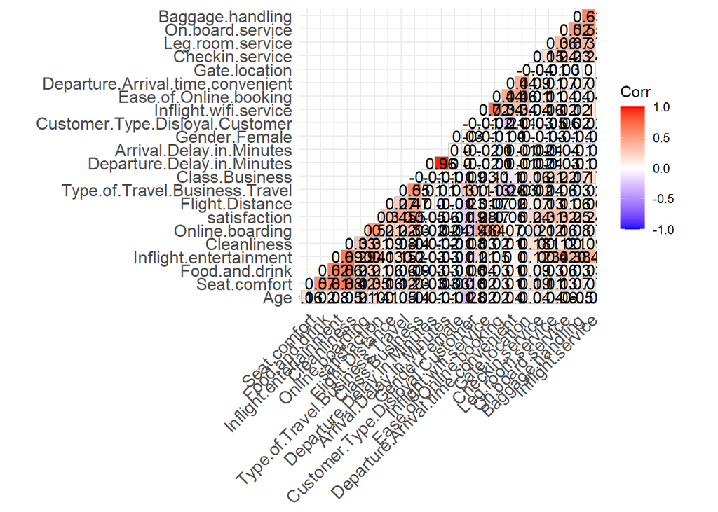

```r
ggcorrplot::ggcorrplot(corr_mat, hc.order = TRUE, type = "lower",
   lab = TRUE)
```

### 3.4.3 Data Splitting

```r
# Splitting dataset
split <- sample.split(airline_df_m_trsf, SplitRatio = 0.8)
train <- subset(airline_df_m_trsf, split == "TRUE")
test <- subset(airline_df_m_trsf, split == "FALSE")
```

We will build the classification model using several classifiers, which is Logistic Regression, Decision Trees and K-Nearest Neighbors (KNN), then evaluate, discuss and compare the results accordingly.

### 3.4.4 Logistic Regression

Logistic Regression is a regression algorithm that predicts the value of target variable (dependent variable) by investigating the relationship between the independent variable and the dependent variable. There are few important assumptions for regression, which is appropriate outcome structure, observations independence, little or no multicollinearity among the independent variables, linearity of independent variables and log odds and large sample size.

Fit logistic regression model using the glm (generalized linear model) function  
**Model Summary:**

```r
logit_model <- glm(satisfaction ~.,
                   family = binomial(link='logit'),
                   data = train)
summary(logit_model)
```

```
##
## Call:
## glm(formula = satisfaction ~ ., family = binomial(link = "logit"),
##     data = train)
##
## Deviance Residuals:
##     Min       1Q   Median       3Q      Max
## -2.7673  -0.4911  -0.1770   0.3863   3.9305
##
## Coefficients:
##                                     Estimate Std. Error  z value Pr(>|z|)
## (Intercept)                       -9.215e+00  8.835e-02 -104.305  < 2e-16 ***
## Gender.Female                     -4.762e-02  2.197e-02   -2.167 0.030227 *
## Customer.Type.Disloyal.Customer   -2.011e+00  3.349e-02  -60.064  < 2e-16 ***
## Age                               -8.432e-03  8.017e-04  -10.517  < 2e-16 ***
## Type.of.Travel.Business.Travel     2.701e+00  3.530e-02   76.526  < 2e-16 ***
## Class.Business                     7.537e-01  2.795e-02   26.964  < 2e-16 ***
## Flight.Distance                   -9.966e-06  1.275e-05   -0.782 0.434372
## Inflight.wifi.service              3.917e-01  1.295e-02   30.254  < 2e-16 ***
## Departure.Arrival.time.convenient -1.159e-01  9.281e-03  -12.491  < 2e-16 ***
## Ease.of.Online.booking            -1.522e-01  1.281e-02  -11.887  < 2e-16 ***
## Gate.location                      3.225e-02  1.034e-02    3.119 0.001812 **
## Food.and.drink                    -3.647e-02  1.205e-02   -3.027 0.002473 **
## Online.boarding                    6.187e-01  1.158e-02   53.452  < 2e-16 ***
## Seat.comfort                       6.172e-02  1.262e-02    4.890 1.01e-06 ***
## Inflight.entertainment             6.994e-02  1.610e-02    4.345 1.39e-05 ***
## On.board.service                   2.947e-01  1.147e-02   25.686  < 2e-16 ***
## Leg.room.service                   2.537e-01  9.639e-03   26.321  < 2e-16 ***
## Baggage.handling                   1.230e-01  1.287e-02    9.554  < 2e-16 ***
## Checkin.service                    3.233e-01  9.653e-03   33.492  < 2e-16 ***
## Inflight.service                   1.251e-01  1.357e-02    9.221  < 2e-16 ***
## Cleanliness                        2.256e-01  1.369e-02   16.476  < 2e-16 ***
## Departure.Delay.in.Minutes         3.561e-03  1.043e-03    3.416 0.000637 ***
## Arrival.Delay.in.Minutes          -8.423e-03  1.033e-03   -8.151 3.62e-16 ***
## ---
## Signif. codes:  0 '***' 0.001 '**' 0.01 '*' 0.05 '.' 0.1 ' ' 1
##
## (Dispersion parameter for binomial family taken to be 1)
##
##     Null deviance: 111235  on 81314  degrees of freedom
## Residual deviance:  54406  on 81292  degrees of freedom
## AIC: 54452
##
## Number of Fisher Scoring iterations: 6
```

**Model Prediction & Evaluation**  
Model evaluation using confusion matrix

```r
# Predict test data
predict_reg <- predict(logit_model,
                       subset(test,
                              select = -c(satisfaction)
                              ),
                       type = "response")
predict_reg <- ifelse(predict_reg >0.5, "satisfied", "neutral or dissatisfied")

# Confusion matrix
confusionMatrix(factor(predict_reg), test$satisfaction)
```

```
## Confusion Matrix and Statistics
##
##                          Reference
## Prediction                neutral or dissatisfied satisfied
##   neutral or dissatisfied                   11574      1605
##   satisfied                                  1149      8261
##
##                Accuracy : 0.8781
##                  95% CI : (0.8737, 0.8823)
##     No Information Rate : 0.5632
##     P-Value [Acc > NIR] : < 2.2e-16
##
##                   Kappa : 0.7509
##
##  Mcnemar's Test P-Value : < 2.2e-16
##
##             Sensitivity : 0.9097
##             Specificity : 0.8373
##          Pos Pred Value : 0.8782
##          Neg Pred Value : 0.8779
##              Prevalence : 0.5632
##          Detection Rate : 0.5124
##    Detection Prevalence : 0.5834
##       Balanced Accuracy : 0.8735
##
##        'Positive' Class : neutral or dissatisfied
##
```

- Based on the confusion matrix, it is observed that the accuracy of the model is high with roughly 88%, and the accuracy is much higher than the no information rate (percentage of the data with the majority class).
- The model also shows high sensitivity and specificity, which means it can correctly predict the customer satisfaction, and only less than 17% of the customers satisfaction are wrongly predicted.
- The Kappa statistic is around 0.75, indicate excellent agreement between individuals.

### 3.4.5 Decision Tree

Build the decision tree model using ctree

```r
dt_model <- ctree(satisfaction ~ ., train)
# plot(dt_model)
```

**Model Prediction & Evaluation**  
Model evaluation using confusion matrix

```r
# Predict test data
predict_dt <- predict(dt_model, test)

# Confusion matrix
dt_m <- table(test$satisfaction, predict_dt)
dt_m
```

```
##                          predict_dt
##                           neutral or dissatisfied satisfied
##   neutral or dissatisfied                   12176       547
##   satisfied                                   604      9262
```

```r
dt_ac <- sum(diag(dt_m)) / sum(dt_m)
print(paste('Accuracy =', dt_ac))
```

```
## [1] "Accuracy = 0.949045995838683"
```

### 3.4.6 K-Nearest Neighbour (KNN)

The K-Nearest Neighbors (KNN) algorithm is a simple, yet powerful, supervised machine learning algorithm. It is used for both classification and regression problems. In classification, the idea is to find the k-number of nearest data points in the training set for a new data point, and then predict the class of the new data point based on the majority class among its k-nearest neighbors.

Fit the KNN model

```r
# Feature scaling
# Normalize the range of independent variables or features of data
train_scale <- scale(train[, 1:22])
test_scale <- scale(test[, 1:22])

# Determine the optimal k value using square root of total observations
# sqrt(NROW(train))
# 285.1596

# KNN (try 285, 286)
knn_model_285 <- knn(train = train_scale,
                     test = test_scale,
                     cl = train$satisfaction,
                     k = 285)
knn_model_286 <- knn(train = train_scale,
                     test = test_scale,
                     cl = train$satisfaction,
                     k = 286)
```

**Model Prediction & Evaluation**  
Model evaluation using confusion matrix

```r
# Confusion Matrix
confusionMatrix(knn_model_285, test$satisfaction)
```

```
## Confusion Matrix and Statistics
##
##                          Reference
## Prediction                neutral or dissatisfied satisfied
##   neutral or dissatisfied                   12237      1625
##   satisfied                                   486      8241
##
##                Accuracy : 0.9065
##                  95% CI : (0.9027, 0.9103)
##     No Information Rate : 0.5632
##     P-Value [Acc > NIR] : < 2.2e-16
##
##                   Kappa : 0.8076
##
##  Mcnemar's Test P-Value : < 2.2e-16
##
##             Sensitivity : 0.9618
##             Specificity : 0.8353
##          Pos Pred Value : 0.8828
##          Neg Pred Value : 0.9443
##              Prevalence : 0.5632
##          Detection Rate : 0.5417
##    Detection Prevalence : 0.6137
##       Balanced Accuracy : 0.8985
##
##        'Positive' Class : neutral or dissatisfied
##
```

```r
confusionMatrix(knn_model_286, test$satisfaction)
```

```
## Confusion Matrix and Statistics
##
##                          Reference
## Prediction                neutral or dissatisfied satisfied
##   neutral or dissatisfied                   12232      1629
##   satisfied                                   491      8237
##
##                Accuracy : 0.9061
##                  95% CI : (0.9023, 0.9099)
##     No Information Rate : 0.5632
##     P-Value [Acc > NIR] : < 2.2e-16
##
##                   Kappa : 0.8067
##
##  Mcnemar's Test P-Value : < 2.2e-16
##
##             Sensitivity : 0.9614
##             Specificity : 0.8349
##          Pos Pred Value : 0.8825
##          Neg Pred Value : 0.9437
##              Prevalence : 0.5632
##          Detection Rate : 0.5415
##    Detection Prevalence : 0.6136
##       Balanced Accuracy : 0.8981
##
##        'Positive' Class : neutral or dissatisfied
##
```

```r
# Improve model and find optimal k value
# i = 1
# k.optm = 1
# for (i in 1:25){
#     knn <-  knn(train = train_scale,
#                 test = test_scale,
#                 cl = train$satisfaction,
#                 k = i)
#     k.optm[i] <- 100 * sum(test$satisfaction == knn)/NROW(test)
#     k = i
#     cat(k, '=', k.optm[i], '\n')
# }
# 1 = 91.39795
# 2 = 91.00065
# 3 = 92.69611
# 4 = 92.39582
# 5 = 92.86242
# 6 = 92.72845
# 7 = 92.99185
# 8 = 92.73769
# 9 = 92.83932
# 10 = 92.8578
# 11 = 92.89014
# 12 = 92.8116
# 13 = 92.91324
# 14 = 92.86704
# 15 = 92.71921
# 16 = 92.64529
# 17 = 92.64529
# 18 = 92.56214
# 19 = 92.64529
# 20 = 92.66839
# 21 = 92.58062
# 22 = 92.4836
# 23 = 92.51132
# 24 = 92.43278
# 25 = 92.46974
# plot(k.optm, type="b", xlab="K- Value", ylab="Accuracy level")

# Optimal k: 7

# KNN (use 7)
knn_model_7 <- knn(train = train_scale,
                    test = test_scale,
                    cl = train$satisfaction,
                    k = 7)

# Confusion Matrix
confusionMatrix(knn_model_7, test$satisfaction)
```

```
## Confusion Matrix and Statistics
##
##                          Reference
## Prediction                neutral or dissatisfied satisfied
##   neutral or dissatisfied                   12294      1237
##   satisfied                                   429      8629
##
##                Accuracy : 0.9262
##                  95% CI : (0.9228, 0.9296)
##     No Information Rate : 0.5632
##     P-Value [Acc > NIR] : < 2.2e-16
##
##                   Kappa : 0.8487
##
##  Mcnemar's Test P-Value : < 2.2e-16
##
##             Sensitivity : 0.9663
##             Specificity : 0.8746
##          Pos Pred Value : 0.9086
##          Neg Pred Value : 0.9526
##              Prevalence : 0.5632
##          Detection Rate : 0.5442
##    Detection Prevalence : 0.5990
##       Balanced Accuracy : 0.9205
##
##        'Positive' Class : neutral or dissatisfied
##
```

- From the output, it can be seen that the highest accuracy is 93% when k = 7, which means that when k = 7, the model correctly predicted the class for 93% of the test samples. Therefore, 7 is the optimal k value for this model.

# 4 Results

# 5 Conclusion

- From the perspective of “Type of Travel,” it is advised that Airlines should give more attention to the four services such as “In-flight Wi-Fi service,” “Ease of Online Booking,” “Departure Arrival time convenient,” and “Gate location” as they are identified to be major sources of dissatisfaction among business travelers.
- For Personal Travel, the majority of the ratings for these services fall between “1” and “3” which indicates that these services are not performing as well as they could. By taking initiative to improve these services, the ratings could be increased from “1” to “3” to “3” to “5”, indicating a significant increase in passenger satisfaction and loyalty.

# 6 Contribution

# 7 Reference